# demo

## Bayesian Online Changepoint detection example

This notebook demonstrates the Bayesian Online Changepoint Detection Algorithm by Adams and MacKay (https://arxiv.org/abs/0710.3742) on some simulated, normally distributed data.

First, we need to import the necessary libraries.

```python
import numpy as np               # numpy to perform everything vectorized
from scipy import stats          # to get the probability distribution of the posterior
import matplotlib.pyplot as plt  # we use matplotlib for plotting
```

We generate a time series with six different segments, where the data in each segment is normally distributed. Both the mean and variance can change between the segments. The true changepoints are at the positions [100, 300, 400, 500, 600]. In one of the segments the varance increases linearly.

```python
T = np.concatenate((
    np.random.normal(0, 1, 100),
    np.random.normal(2, 0.3, 200),
    np.random.normal(2, 1, 100),
    np.random.normal(-1, 0.2, 100),
    np.random.normal(-1, np.linspace(0.2, 1, 100)),
    np.random.normal(-1, 1, 100)
))

true_changepoints = [100, 300, 400, 500, 600]
```

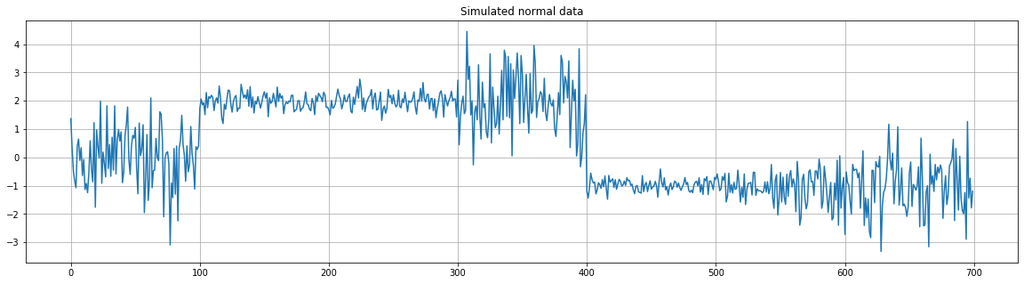

```python
fig, ax = plt.subplots(1, 1, figsize=(20, 5))
ax.set_title("Simulated normal data")
ax.plot(T)
ax.grid(True)
```

Next we will need to define the necessary classes. We will use a constant hazard function (this means that the probability of a changepoint occuring does not depend on the run length and could happen equally likely at any time. Further, we assume a normal likelihood with unknown mean and variance for the data. The corresponding conjugate prior is a Normal-Inverse-Gamma distribution. The resulting posterior distribution is a Students T distribution, which we use to get the probability of the new observation.

```python
class ConstantHazard:
    """ In case that the changpoints are exponentially distributed, i.e. at each time step the probability of a changepoint is the same,
    then the hazard function is just a constant one over the average distance between changepoints
    """
    def __init__(self, _lambda):
        self._lambda = _lambda

    def __call__(self, r):
        """
        Args:
          r: The length of the current run (np.ndarray or scalar)
        Returns:
          p: Changepoint Probabilities(np.ndarray with shape = r.shape)
        """
        if isinstance(r, np.ndarray):
            r[:] = 1
        else:
            r = 1

        return r / self._lambda
```

```python
class StudentT:
    """Posterior if the Likelihood function is a Normal with
    unknown mean and variance and the (conjugate) prior a Normal-Inverse-Gamma.
    """

    def __init__(self, alpha, beta, kappa, mu):
        """ Mean of (normal) likelihood function was estimated from kappa observations
        with sample mean mu, variance was estimated from 2*alpha observations with
        sample mean mu and sum of sqared deviations 2*beta.
        """
        self.alpha0 = self.alpha = np.array([alpha])
        self.beta0 = self.beta = np.array([beta])
        self.kappa0 = self.kappa = np.array([kappa])
        self.mu0 = self.mu = np.array([mu])

        self._size = 1

    def pdf(self, data):
        scale = self.get_scale()
        mask = np.abs(data - self.mu) < 5 * scale

        pdf = np.zeros(self.mu.size, dtype=float)
        pdf[:] = 1e-10
        pdf[mask] = stats.t.pdf(
            x=data,
            df=2 * self.alpha[mask],
            loc=self.mu[mask],
            scale=scale[mask],
        )
        return pdf

    def get_scale(self):
        return np.sqrt(self.beta * (self.kappa + 1) / (self.alpha * self.kappa))

    def update_theta(self, data):
        muT0 = np.concatenate(
            (self.mu0, (self.kappa * self.mu + data) / (self.kappa + 1))
        )
        kappaT0 = np.concatenate((self.kappa0, self.kappa + 1.0))
        alphaT0 = np.concatenate((self.alpha0, self.alpha + 0.5))
        betaT0 = np.concatenate(
            (
                self.beta0,
                self.beta
                + (self.kappa * (data - self.mu) ** 2) / (2.0 * (self.kappa + 1.0)),
            )
        )

        self.mu = muT0
        self.kappa = kappaT0
        self.alpha = alphaT0
        self.beta = betaT0

    def prune(self, t):
        """Prunes memory before t.
        """
        self.mu = self.mu[: t + 1]
        self.kappa = self.kappa[: t + 1]
        self.alpha = self.alpha[: t + 1]
        self.beta = self.beta[: t + 1]
```

```python
# Copyright (c) 2014 Johannes Kulick
# Copyright (c) 2017-2018 David Tolpin
# Copyright (c) 2020 Max Mihailescu
#
# Code initally borrowed from:
#    https://github.com/hildensia/bayesian_changepoint_detection and
#    https://github.com/dtolpin/bocd
# under the MIT license.

class BayesianDetector:
    def __init__(self, hazard_function, observation_likelihood, tail_threshold):
        """ Initializes the detector with zero observations.
        """
        self._t0 = 0
        self._t = -1
        self._growth_probs = np.array([1.0])
        self._hazard_function = hazard_function
        self._observation_likelihood = observation_likelihood
        self._tail_threshold = tail_threshold
        self._last_cp = 0

    def update(self, x):
        """ When a new data point x arrives, we need to compute the new run length probabilities.
        """
        self._t += 1

        t = self._t - self._t0

        # allocate enough space
        if len(self._growth_probs) == t + 1:
            self._growth_probs = np.resize(self._growth_probs, (t + 1) * 2)

        # Evaluate the predictive distribution for the new datum under each of
        # the parameters.  This is the standard thing from Bayesian inference.
        pred_probs = self._observation_likelihood.pdf(x)

        # Evaluate the hazard function for this interval
        H = self._hazard_function(t + 1)

        # Evaluate the probability that there *was* a changepoint and we're
        # accumulating the mass back down at r = 0
        self._growth_probs[self._growth_probs < 1e-10] = 0
        cp_prob = np.sum(self._growth_probs[0 : t + 1] * pred_probs * H)
        # Evaluate the growth probabilities - shift the probabilities down and to
        # the right, scaled by the hazard function and the predictive
        # probabilities.
        self._growth_probs[1 : t + 2] = (
            self._growth_probs[0 : t + 1] * pred_probs * (1 - H)
        )
        # Put back changepoint probability
        self._growth_probs[0] = cp_prob
        self._growth_probs[t + 2 :] = 0

        # Renormalize the run length probabilities for improved numerical
        # stability.
        total_prob = np.sum(self._growth_probs[0 : t + 2])
        if total_prob >= 1e-15:
            self._growth_probs[0 : t + 2] = self._growth_probs[0 : t + 2] / total_prob
        else:
            self._growth_probs[0] = 1
            self._growth_probs[1 : t + 2] = 0

        # Update the parameter sets for each possible run length.
        self._observation_likelihood.update_theta(x)

        # If the tail probability (i.e. the probability of being in a really long run)
        # is very small, we can assume it is zero to consume memory and especially the
        # need of evaluating the probability for those values.
        cdf = np.cumsum(self._growth_probs[0 : t + 2])
        tail = np.flatnonzero(cdf > 1 - self._tail_threshold)
        if tail.size > 1:
            self.prune(tail[1] - 1)


    def get_growth_probabilities(self):
        return self._growth_probs.copy()

    def predictive_mean(self):
        MAP = np.argmax(self._growth_probs)
        return self._observation_likelihood.mu[MAP]

    def predictive_std(self):
        MAP = np.argmax(self._growth_probs)
        return self._observation_likelihood.get_scale()[MAP]


    def prune(self, t0):
        """ Prunes memory before time._t0. That is, pruning at t=0
        does not change the memory. One should prune at times
        which are likely to correspond to changepoints.
        """
        self._growth_probs[t0 + 1 :] = 0
        self._growth_probs[: t0 + 1] = self._growth_probs[: t0 + 1] / np.sum(
            self._growth_probs[: t0 + 1]
        )
        self._observation_likelihood.prune(t0)
        self._t0 = self._t - t0 + 1

    def detect(self, tail_slope, min_tail_probability):
        time_since_last_cp = self._t - self._last_cp
        tail = time_since_last_cp * tail_slope
        tail_probability = np.sum(self._growth_probs[int(time_since_last_cp):])
        if tail_probability < min_tail_probability:
            MAP = np.argmax(self._growth_probs)
            self._last_cp = self._t - MAP
            return MAP
        else:
            return -1
```

We can now create the detector. We will take the first 10 samples to estimate the mean and variance of our signal, and choose 100 as the mean changepoint distance. In a real setting you obviously don't know the distance between changepoints as exactly as we do here, so you have to guess it using the prior knowledge of the problem.

```python
def create_detector(T, init_size, mean_changepoint_distance):
    hazard = ConstantHazard(mean_changepoint_distance)

    init_mean, init_var = T[:init_size].mean(), T[:init_size].var()
    if init_var < 1e-7:
        init_var = 0.01

    kappa = init_size
    alpha = init_size * 0.5
    mu = init_mean
    beta = 0.5 * init_size * init_var

    observation_likelihood = StudentT(alpha, beta, kappa, mu)

    tail_threshold = 1e-4
    detector = BayesianDetector(hazard, observation_likelihood, tail_threshold)

    print("Estimated mean:", init_mean, "- Estimated standard deviation:", np.sqrt(init_var))
    return detector

init_size=10
mean_changepoint_distance = 100
detector = create_detector(T, init_size, mean_changepoint_distance)
```

```
Estimated mean: -0.007565563187691293 - Estimated standard deviation: 0.7201267098422924
```

Now we weill read in the rest of the time series sequencially and perform online changepoint detection.

```python
rec_probs = 3*mean_changepoint_distance

# First, initialize the arrays where we will store the predictive probabilities and quantities such as the mean.
growth_matrix = np.zeros((T.size - init_size, rec_probs), dtype=float)
predictive_mean = np.zeros(T.size - init_size, dtype=float)
predictive_std = np.zeros(T.size - init_size, dtype=float)
tail_probability = np.zeros(T.size - init_size, dtype=float)

# Here we will store the changepoints that were found. Each CP is a tuple with the first value being
# the moment we got notified and the second value the position where it occurred.
cps = [(0, 0)]

for i, x in enumerate(T[init_size:]):
    if i % 100 == 0:
        print(f"{i}/{T.size - init_size}")

    # Update the detector using the newly arrived value.
    detector.update(x)

    tail_slope = 0.8
    min_tail_probability = 0.1
    # Detect how long ago a changepoint occurred. If this value is negative,
    # then no changepoint was found in this iteration.
    new_cp = detector.detect(tail_slope, min_tail_probability)

    # Get the run length probabilities
    growth_probs = detector.get_growth_probabilities()

    time_since_last_cp = i - cps[-1][1]
    tail = time_since_last_cp * tail_slope
    tail_probability[i] = np.sum(growth_probs[int(time_since_last_cp):])

    if new_cp >= 0:
        cps.append((i, i-new_cp))

    # Store the prediction values
    l = min(growth_probs.size, rec_probs)
    growth_matrix[i, :l] = growth_probs[:l]
    predictive_mean[i] = detector.predictive_mean()
    predictive_std[i] = detector.predictive_std()

print(f"{T.size - init_size}/{T.size - init_size}")
```

```
0/690
100/690
200/690
300/690
400/690
500/690
600/690
690/690
```

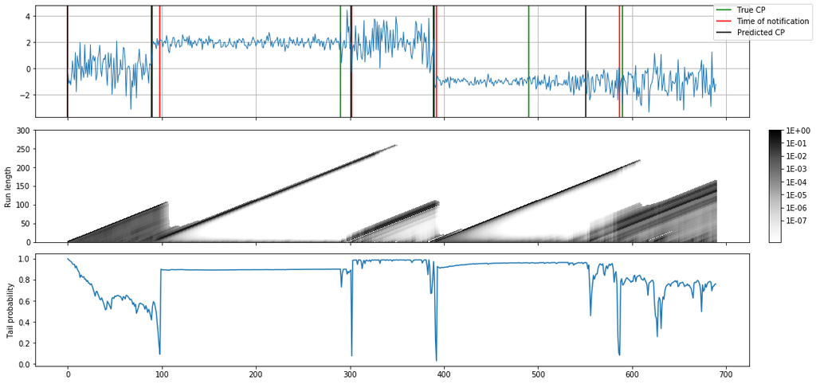

```python
%matplotlib inline

from mpl_toolkits.axes_grid1 import make_axes_locatable
import matplotlib.ticker as ticker

fig, ax = plt.subplots(3, 1, sharex=True, figsize=(15, 7), constrained_layout=True)

ax[0].plot(T[init_size:], lw=1)
ax[0].vlines([cp - init_size for cp in true_changepoints], color="green", ymin=0, ymax=1, transform=ax[0].get_xaxis_transform(), label="True CP")
ax[0].vlines([cp[0] for cp in cps], color="red", ymin=0, ymax=1, transform=ax[0].get_xaxis_transform(), label="Time of notification")
ax[0].vlines([cp[1] for cp in cps], color="black", ymin=0, ymax=1, transform=ax[0].get_xaxis_transform(), label="Predicted CP")
ax[0].grid(True)

ax[1].set_ylabel("Run length")
cmap = plt.get_cmap("Greys")
gmplot = growth_matrix.T.copy()
gmplot = np.log(gmplot, where=gmplot > 0, out=np.full(gmplot.shape, -np.inf))
im = ax[1].pcolormesh(gmplot, cmap=cmap, vmin=-20, vmax=0)

cb = fig.colorbar(im, ax=ax[1])
cb.set_ticks([np.log(t) for t in [1, 0.1, 0.01, 0.001, 0.0001, 1e-5, 1e-6, 1e-7]])
cb.formatter = ticker.FuncFormatter(lambda x, pos: "{:.0E}".format(np.exp(x)))
cb.update_ticks()

ax[2].plot(tail_probability)
ax[2].set_ylabel("Tail probability")

fig.legend()

plt.show()
```

```python
!jupyter nbconvert --to html demo.ipynb
```

```
[NbConvertApp] Converting notebook demo.ipynb to html
[NbConvertApp] Writing 426273 bytes to demo.html
```